## PCA: test on repeated measurements

**Mar 9, 2018**

```r
library(tidyverse)
theme_set(theme_bw(base_size=12)) # set default ggplot2 theme
library(egg) # required to arrange plots side-by-side
library(grid) # required to draw arrows
library(plyr); library(dplyr)
```

# 1. PCA of the iris data set

The `iris` dataset has four measurements per observational unit (iris plant):

```r
head(iris)
```

```
##   Sepal.Length Sepal.Width Petal.Length Petal.Width Species
## 1          5.1         3.5          1.4         0.2  setosa
## 2          4.9         3.0          1.4         0.2  setosa
## 3          4.7         3.2          1.3         0.2  setosa
## 4          4.6         3.1          1.5         0.2  setosa
## 5          5.0         3.6          1.4         0.2  setosa
## 6          5.4         3.9          1.7         0.4  setosa
```

```r
ddply(iris,.(Species),summarize,tol_in_group=length(Species))
```

```
##      Species tol_in_group
## 1     setosa           50
## 2 versicolor           50
## 3  virginica           50
```

```r
# repeated2: make each observation repeated twice
iris.selected <- iris[1:150,]
iris.repeated2 <- iris.selected[rep(seq_len(nrow(iris.selected)), each=2),] # each is repeated twice
head(iris.repeated2)
```

```
##     Sepal.Length Sepal.Width Petal.Length Petal.Width Species
## 1            5.1         3.5          1.4         0.2  setosa
## 1.1          5.1         3.5          1.4         0.2  setosa
## 2            4.9         3.0          1.4         0.2  setosa
## 2.1          4.9         3.0          1.4         0.2  setosa
## 3            4.7         3.2          1.3         0.2  setosa
## 3.1          4.7         3.2          1.3         0.2  setosa
```

```r
# repeated3: make versicolor observations repeated for 6 times
iris.selected <- iris[50:100,]
temp <- iris.selected[rep(seq_len(nrow(iris.selected)), each=5),] # each is repeated twice
iris.repeated3 <- rbind(temp,iris) # each is repeated for three times
head(iris.repeated3)
```

```
##      Sepal.Length Sepal.Width Petal.Length Petal.Width    Species
## 50              5         3.3          1.4         0.2     setosa
## 50.1            5         3.3          1.4         0.2     setosa
## 50.2            5         3.3          1.4         0.2     setosa
## 50.3            5         3.3          1.4         0.2     setosa
## 50.4            5         3.3          1.4         0.2     setosa
## 51              7         3.2          4.7         1.4 versicolor
```

The basic steps in PCA are to (i) prepare a data frame that holds only the numerical columns of interest, (ii) scale the data to 0 mean and unit variance, and (iii) do the PCA with the function `prcomp()`:

```r
iris %>% select(-Species) %>% # remove Species column
  scale() %>%                 # scale to 0 mean and unit variance
  prcomp() ->                 # do PCA
  pca                         # store result as `pca`

# iris.repeated2
iris.repeated2 %>% select(-Species) %>% # remove Species column
  scale() %>%                 # scale to 0 mean and unit variance
  prcomp() ->                 # do PCA
  pca1                         # store result as `pca`

# iris.repeated3
iris.repeated3 %>% select(-Species) %>% # remove Species column
  scale() %>%                 # scale to 0 mean and unit variance
  prcomp() ->                 # do PCA
  pca2                        # store result as `pca`

# now display the results from the PCA analysis
pca
```

```
## Standard deviations (1, .., p=4):
## [1] 1.7083611 0.9560494 0.3830886 0.1439265
##
## Rotation (n x k) = (4 x 4):
##                     PC1         PC2        PC3        PC4
## Sepal.Length  0.5210659 -0.37741762  0.7195664  0.2612863
## Sepal.Width  -0.2693474 -0.92329566 -0.2443818 -0.1235096
## Petal.Length  0.5804131 -0.02449161 -0.1421264 -0.8014492
## Petal.Width   0.5648565 -0.06694199 -0.6342727  0.5235971
```

```r
pca1 # iris.repeated2
```

```
## Standard deviations (1, .., p=4):
## [1] 1.7083611 0.9560494 0.3830886 0.1439265
##
## Rotation (n x k) = (4 x 4):
##                     PC1        PC2        PC3        PC4
## Sepal.Length  0.5210659 0.37741762  0.7195664 -0.2612863
## Sepal.Width  -0.2693474 0.92329566 -0.2443818  0.1235096
## Petal.Length  0.5804131 0.02449161 -0.1421264  0.8014492
## Petal.Width   0.5648565 0.06694199 -0.6342727 -0.5235971
```

```r
pca2 # iris.repeated3
```

```
## Standard deviations (1, .., p=4):
## [1] 1.6343451 1.0286029 0.4871360 0.1832775
##
## Rotation (n x k) = (4 x 4):
##                     PC1         PC2        PC3        PC4
## Sepal.Length  0.5318454  0.32191302  0.7487618  0.2299309
## Sepal.Width  -0.1206033  0.94353528 -0.2805690 -0.1283629
## Petal.Length  0.6019377 -0.07542607 -0.1557374 -0.7795689
## Petal.Width   0.5833235 -0.02059355 -0.5799850  0.5682667
```

The main results from PCA are the standard deviations and the rotation matrix. We will talk about them below. First, however, let’s plot the data in the principal components. Specifically, we will plot PC2 vs. PC1. The rotated data are available as `pca$x`:

```r
head(pca$x)
```

```
##            PC1        PC2         PC3          PC4
## [1,] -2.257141 -0.4784238  0.12727962  0.024087508
## [2,] -2.074013  0.6718827  0.23382552  0.102662845
## [3,] -2.356335  0.3407664 -0.04405390  0.028282305
## [4,] -2.291707  0.5953999 -0.09098530 -0.065735340
## [5,] -2.381863 -0.6446757 -0.01568565 -0.035802870
## [6,] -2.068701 -1.4842053 -0.02687825  0.006586116
```

```r
head(pca1$x)# iris.repeated2
```

```
##           PC1        PC2         PC3         PC4
## 1   -2.260925  0.4792259  0.12749300 -0.02412789
## 1.1 -2.260925  0.4792259  0.12749300 -0.02412789
## 2   -2.077490 -0.6730091  0.23421751 -0.10283495
## 2.1 -2.077490 -0.6730091  0.23421751 -0.10283495
## 3   -2.360285 -0.3413377 -0.04412775 -0.02832972
## 3.1 -2.360285 -0.3413377 -0.04412775 -0.02832972
```

```r
head(pca2$x)# iris.repeated3
```

```
##            PC1       PC2       PC3         PC4
## 50   -3.411313 0.7832518 0.2432702 0.073225641
## 50.1 -3.411313 0.7832518 0.2432702 0.073225641
## 50.2 -3.411313 0.7832518 0.2432702 0.073225641
## 50.3 -3.411313 0.7832518 0.2432702 0.073225641
## 50.4 -3.411313 0.7832518 0.2432702 0.073225641
## 51    1.294030 1.2694435 0.8031511 0.006340659
```

As we can see, these data don’t tell us to which species which observation belongs. We have to add the species information back in:

```r
# add species information back into PCA data
pca_data <- data.frame(pca$x, Species=iris$Species)
head(pca_data)
```

```
##         PC1        PC2         PC3          PC4 Species
## 1 -2.257141 -0.4784238  0.12727962  0.024087508  setosa
## 2 -2.074013  0.6718827  0.23382552  0.102662845  setosa
## 3 -2.356335  0.3407664 -0.04405390  0.028282305  setosa
## 4 -2.291707  0.5953999 -0.09098530 -0.065735340  setosa
## 5 -2.381863 -0.6446757 -0.01568565 -0.035802870  setosa
## 6 -2.068701 -1.4842053 -0.02687825  0.006586116  setosa
```

```r
pca_data1 <- data.frame(pca1$x, Species=iris.repeated2$Species)
head(pca_data1)# iris.repeated2
```

```
##           PC1        PC2         PC3         PC4 Species
## 1   -2.260925  0.4792259  0.12749300 -0.02412789  setosa
## 1.1 -2.260925  0.4792259  0.12749300 -0.02412789  setosa
## 2   -2.077490 -0.6730091  0.23421751 -0.10283495  setosa
## 2.1 -2.077490 -0.6730091  0.23421751 -0.10283495  setosa
## 3   -2.360285 -0.3413377 -0.04412775 -0.02832972  setosa
## 3.1 -2.360285 -0.3413377 -0.04412775 -0.02832972  setosa
```

```r
pca_data2 <- data.frame(pca2$x, Species=iris.repeated3$Species)
head(pca_data2)# iris.repeated3
```

```
##            PC1       PC2       PC3         PC4    Species
## 50   -3.411313 0.7832518 0.2432702 0.073225641     setosa
## 50.1 -3.411313 0.7832518 0.2432702 0.073225641     setosa
## 50.2 -3.411313 0.7832518 0.2432702 0.073225641     setosa
## 50.3 -3.411313 0.7832518 0.2432702 0.073225641     setosa
## 50.4 -3.411313 0.7832518 0.2432702 0.073225641     setosa
## 51    1.294030 1.2694435 0.8031511 0.006340659 versicolor
```

Now we can plot as usual:

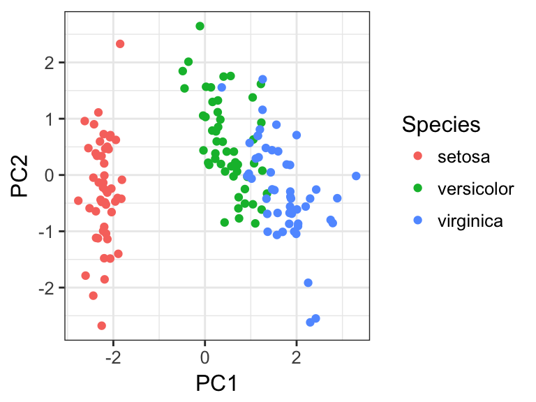

```r
ggplot(pca_data, aes(x=PC1, y=PC2, color=Species)) + geom_point()
```

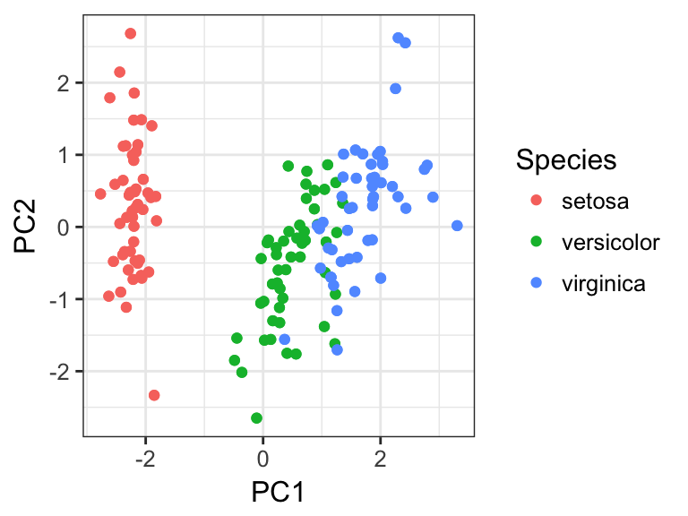

```r
ggplot(pca_data1, aes(x=PC1, y=PC2, color=Species)) + geom_point()# iris.repeated2
```

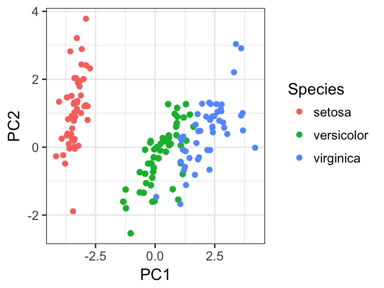

```r
ggplot(pca_data2, aes(x=PC1, y=PC2, color=Species)) + geom_point()# iris.repeated2
```

Next, let’s look at the rotation matrx:

```r
pca$rotation
```

```
##                     PC1         PC2        PC3        PC4
## Sepal.Length  0.5210659 -0.37741762  0.7195664  0.2612863
## Sepal.Width  -0.2693474 -0.92329566 -0.2443818 -0.1235096
## Petal.Length  0.5804131 -0.02449161 -0.1421264 -0.8014492
## Petal.Width   0.5648565 -0.06694199 -0.6342727  0.5235971
```

```r
pca1$rotation# iris.repeated2
```

```
##                     PC1        PC2        PC3        PC4
## Sepal.Length  0.5210659 0.37741762  0.7195664 -0.2612863
## Sepal.Width  -0.2693474 0.92329566 -0.2443818  0.1235096
## Petal.Length  0.5804131 0.02449161 -0.1421264  0.8014492
## Petal.Width   0.5648565 0.06694199 -0.6342727 -0.5235971
```

```r
pca2$rotation# iris.repeated3
```

```
##                     PC1         PC2        PC3        PC4
## Sepal.Length  0.5318454  0.32191302  0.7487618  0.2299309
## Sepal.Width  -0.1206033  0.94353528 -0.2805690 -0.1283629
## Petal.Length  0.6019377 -0.07542607 -0.1557374 -0.7795689
## Petal.Width   0.5833235 -0.02059355 -0.5799850  0.5682667
```

It tells us how much each variable contributes to each principal component. For example, `Sepal.Width` contributes little to PC1 but makes up much of PC2. Often it is helpful to plot the rotation matrix as arrows. This can be done as follows:

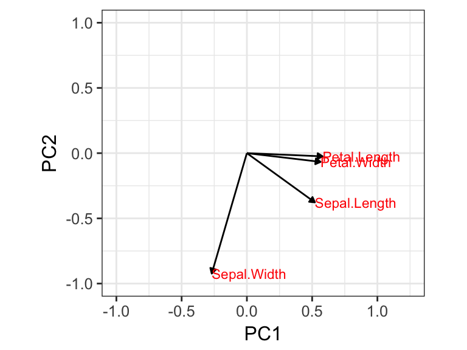

```r
# capture the rotation matrix in a data frame
rotation_data <- data.frame(pca$rotation, variable=row.names(pca$rotation))
# define a pleasing arrow style
arrow_style <- arrow(length = unit(0.05, "inches"),
                     type = "closed")
# now plot, using geom_segment() for arrows and geom_text for labels
ggplot(rotation_data) +
  geom_segment(aes(xend=PC1, yend=PC2), x=0, y=0, arrow=arrow_style) +
  geom_text(aes(x=PC1, y=PC2, label=variable), hjust=0, size=3, color='red') +
  xlim(-1.,1.25) +
  ylim(-1.,1.) +
  coord_fixed() # fix aspect ratio to 1:1
```

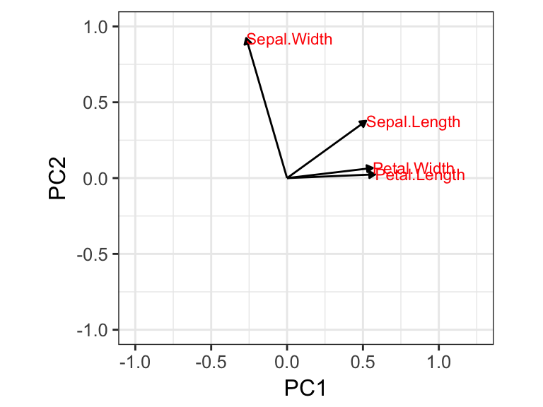

```r
# iris.repeated2
# capture the rotation matrix in a data frame
rotation_data1 <- data.frame(pca1$rotation, variable=row.names(pca1$rotation))
# now plot, using geom_segment() for arrows and geom_text for labels
ggplot(rotation_data1) +
  geom_segment(aes(xend=PC1, yend=PC2), x=0, y=0, arrow=arrow_style) +
  geom_text(aes(x=PC1, y=PC2, label=variable), hjust=0, size=3, color='red') +
  xlim(-1.,1.25) +
  ylim(-1.,1.) +
  coord_fixed() # fix aspect ratio to 1:1
```

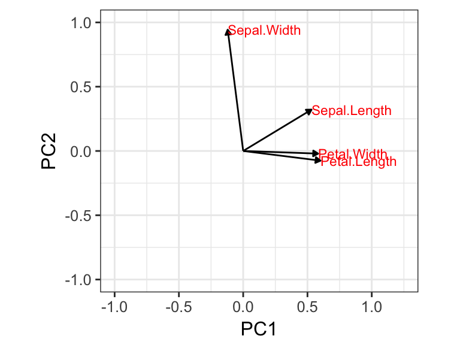

```r
# iris.repeated3
# capture the rotation matrix in a data frame
rotation_data1 <- data.frame(pca2$rotation, variable=row.names(pca1$rotation))
# now plot, using geom_segment() for arrows and geom_text for labels
ggplot(rotation_data1) +
  geom_segment(aes(xend=PC1, yend=PC2), x=0, y=0, arrow=arrow_style) +
  geom_text(aes(x=PC1, y=PC2, label=variable), hjust=0, size=3, color='red') +
  xlim(-1.,1.25) +
  ylim(-1.,1.) +
  coord_fixed() # fix aspect ratio to 1:1
```

We can now see clearly that `Petal.Length`, `Petal.Width`, and `Sepal.Length` all contribute to PC1, and `Sepal.Width` dominates PC2.

Finally, we want to look at the percent variance explained. The `prcomp()` function gives us standard deviations (stored in `pca$sdev`). To convert them into percent variance explained, we square them and then divide by the sum over all squared standard deviations:

```r
percent <- 100*pca$sdev^2/sum(pca$sdev^2)
percent
```

```
## [1] 72.9624454 22.8507618  3.6689219  0.5178709
```

```r
percent1 <- 100*pca1$sdev^2/sum(pca1$sdev^2)
percent1# iris.repeated2
```

```
## [1] 72.9624454 22.8507618  3.6689219  0.5178709
```

```r
percent2 <- 100*pca2$sdev^2/sum(pca2$sdev^2)
percent2# iris.repeated3
```

```
## [1] 66.7771013 26.4505964  5.9325366  0.8397657
```

The first component explains 73% of the variance, the second 23%, the third 4% and the last 0.5%. We can visualize these results nicely in a bar plot:

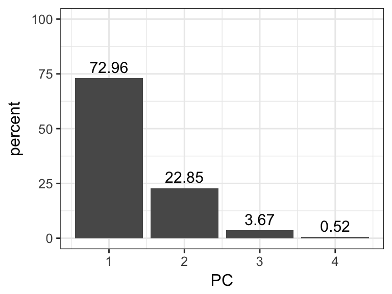

```r
perc_data <- data.frame(percent=percent, PC=1:length(percent))
ggplot(perc_data, aes(x=PC, y=percent)) +
  geom_col() +
  geom_text(aes(label=round(percent, 2)), size=4, vjust=-.5) +
  ylim(0, 100)
```

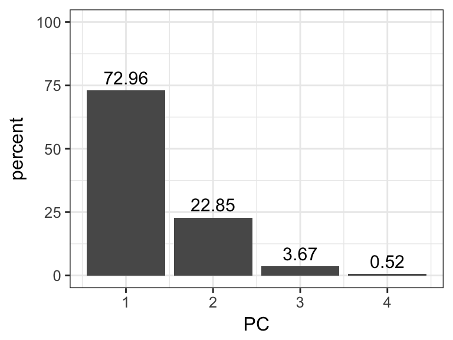

```r
perc_data1 <- data.frame(percent=percent1, PC=1:length(percent1))
ggplot(perc_data1, aes(x=PC, y=percent)) +
  geom_col() +
  geom_text(aes(label=round(percent, 2)), size=4, vjust=-.5) +
  ylim(0, 100)# iris.repeated2
```

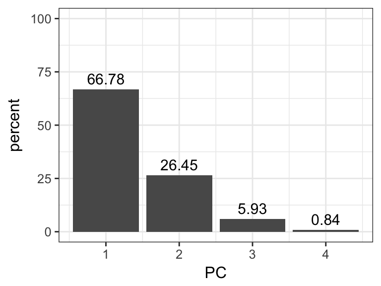

```r
perc_data2 <- data.frame(percent=percent2, PC=1:length(percent2))
ggplot(perc_data2, aes(x=PC, y=percent)) +
  geom_col() +
  geom_text(aes(label=round(percent, 2)), size=4, vjust=-.5) +
  ylim(0, 100)# iris.repeated3
```

*Conclusion: we do not perform PCA on repeated measurements, but will select one measurement for each lesion and then calculate the pca results for the rest of observations.*